# Analysis Code

Lorenzo Ricolfi

The following analysis steps were removed from the present file because out of its scope:

- Data wrangling and cleaning
- Exploratory analyses
- Effect size conversion & calculation

# First Research Question

**Question:** How does exposure to per- and polyfluoroalkyl substances (PFAS) affect human health?

**Objective:** To evaluate the magnitude and variability of associations between PFAS exposure and adverse human health outcomes based on multiple meta-analyses.

BUT,

Before looking at the meta-analytic model, I have to tell you that:

- I run a meta-analytic model including all effect sizes and then tested their impact on the overall result.
- I found that the strategy we used to convert effect size metrics into logOR has an impact on the overall results.
- Thus, I had to trim the dataset to only original logOR and OR effect size metrics.

Here we can see the impact of effect size metrics (moderator) and the reason why I decided to trim the dataset to only original logOR and OR effect size metrics:

```r
mod_es <- rma.mv(yi = logOR,
              V = se^2,
              random = list(~1|ma_id,
                            ~1|ma_e_id),
              mods = ~ ma_es_measure - 1,
              data = ma_e_details)
```

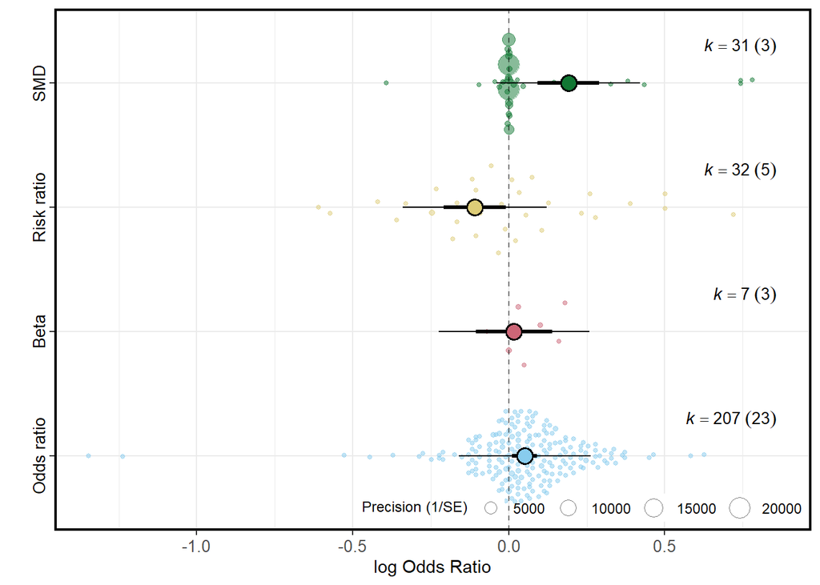

## The Meta-analytic Model

We are fitting a multilevel random-effects model via *rma.mv()* from the *metafor* package.

Random effect structure:

- **~1 | ma_id** introduces a random intercept for each meta-analysis. It acknowledges that different meta-analyses may have different baseline effects due to design, populations, etc.
- **~1 | ma_e_id** introduces a random intercept for each effect size estimate within a meta-analysis. It accounts for non-independence of estimates within the same meta-analysis.

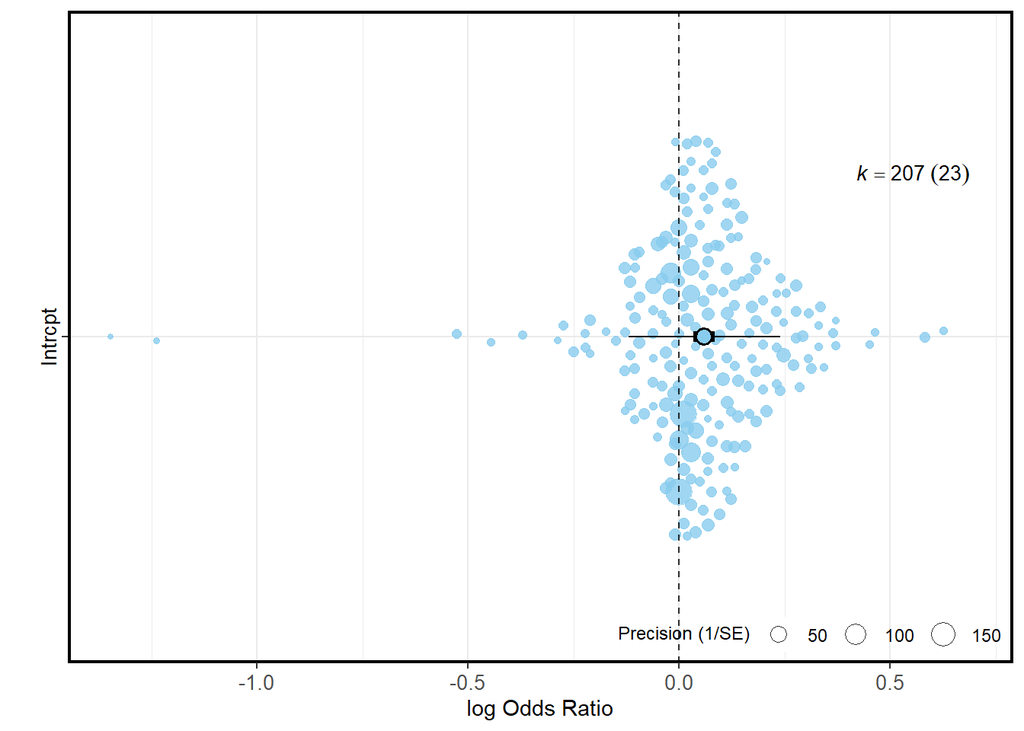

```r
dat <- ma_e_details %>%
  filter(ma_es_measure %in% c("Odds ratio", "log Odds ratio") )

mod_no_transf <- rma.mv(yi = logOR,
                        V = se^2,
                        random = list(~1|ma_id,
                                      ~1|ma_e_id),
                        data = dat,
                        test = "t")

summary(mod_no_transf)
```

## Analysis of Heterogeneity

```
##   I2_Total   I2_ma_id I2_ma_e_id
##   83.93146   17.33652   66.59494
```

```
## I² (between studies): 17.3 %
```

```
## I² (within studies): 66.6 %
```

## Summary Results

**1)** Exposure to PFAS showed a weak but significant association with increased odds of an adverse health outcome, across all meta-analyses included. Specifically, a 6% (CI 3.5% - 8.9%) increase.

**2)** Most of the variability in logORs comes from within meta-analyses (66.6%).

# Second Research Question

## Chemicals

**Question:** Is there any difference in the significance and strength of the association with adverse health outcomes among individual PFAS?

**Question:** What individual PFAS are significantly associated with adverse health outcomes?

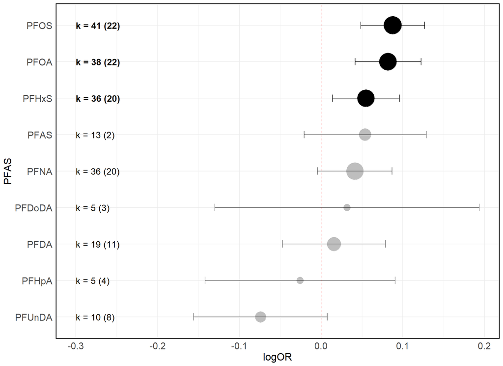

```r
mod2 <- rma.mv(yi = logOR,
               V = se^2,
               mods = ~ chemical_id -1,
               random = list(~1|ma_id,
                             ~1|ma_e_id),
               test = "t",
               sparse = T,
               data = dat,
               control = list(iter.max = 1000,
                              rel.tol = 1e-8))

summary(mod2)
```

## Health Outcome Class

**Question:** Is there any difference in the significance and strength of the association with PFAS exposure among individual classes (lower level) of adverse health outcomes?

**Question:** What classes (lower level) of adverse health outcomes are significantly associated with PFAS exposure?

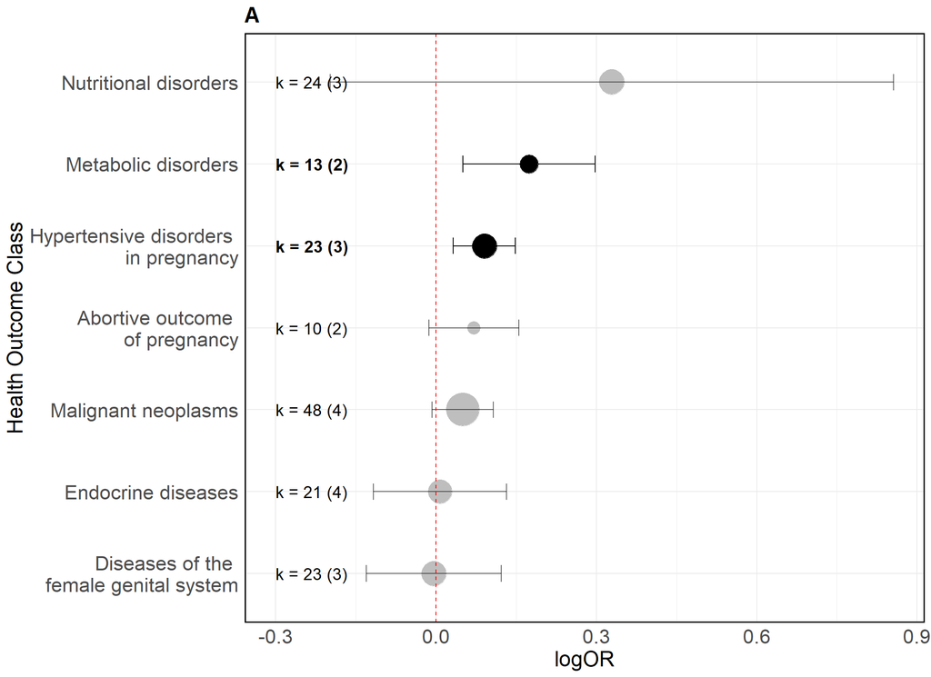

```r
mod3 <- rma.mv(yi = logOR,
                  V = se^2,
                  mods = ~ health_outcome_class -1,
                  random = list(~1|ma_id,
                                ~1|ma_e_id),
                  test = "t",
                  sparse = T,
                  data = dat,
                  control = list(iter.max = 1000,
                                  rel.tol = 1e-8))

summary(mod3)
```

## Health Outcome Group

**Question:** Is there any difference in the significance and strength of the association with PFAS exposure among individual groups (higher level) of adverse health outcomes?

**Question:** What groups (higher level) of adverse health outcome are significantly associated with PFAS exposure?

[figure not shown]

```r
mod4 <- rma.mv(yi = logOR,
                  V = se^2,
                  mods = ~ health_outcome_group -1,
                   random = list(~1|ma_id,
                                 ~1|ma_e_id),
                   test = "t",
                   sparse = T,
                   data = dat,
                   control = list(iter.max = 1000,
                                  rel.tol = 1e-8))

summary(mod4)
```

## Summary Results

**1)** We found statistically significant differences in the associations between individual PFAS and adverse health outcomes (p < 0.0001).

**3)** We also found significant differences in the associations between PFAS exposure and specific classes of adverse health outcomes (p = 0.0005). Classes is the lower level of classification according to the International Statistical Classification of Diseases (ICD) 2024 version – 11th revision.

**4)** The following outcome classes were significantly associated with PFAS exposure: - Hypertensive diseases: p-val = 0.0024 - Metabolic disorders: p-val = 0.0055 - Oedema, proteinuria, or hypertensive disorders in pregnancy, childbirth, or the puerperium: p-val = 0.0020 - Osteopathies or chondropathies: p-val = 0.0410

**5)** Statistically significant differences were also observed in the associations between PFAS exposure and broader groups of adverse health outcomes (p = 0.0014). Groups is the higher level of classification according to the International Statistical Classification of Diseases (ICD) 2024 version – 11th revision.

# Third Research Question

**Question:** What are the significant associations between individual PFAS and specific health outcomes, and how strong are these correlations?

**Objective:** To determine significant PFAS-health outcome correlations and assess the strength of these relationships.

BUT

Before addressing our third research question through quantitative analysis, we first perform a qualitative assessment to determine the number of meta-analyses and effect sizes available for each combination of individual PFAS and health outcome group.

## Qualitative Synthesis

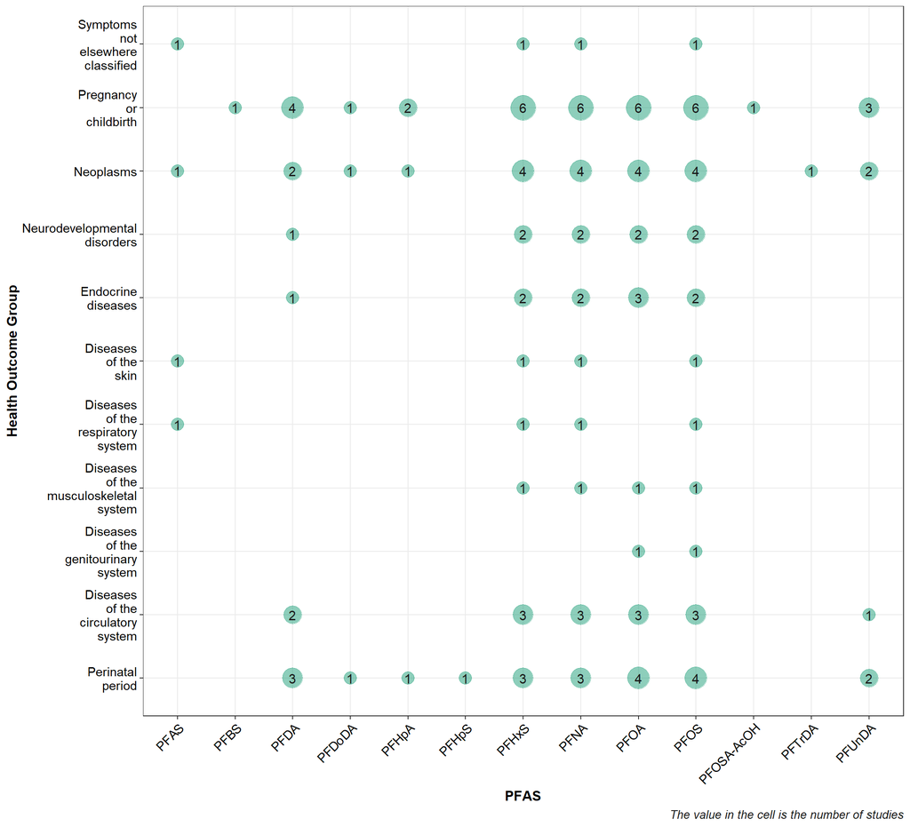

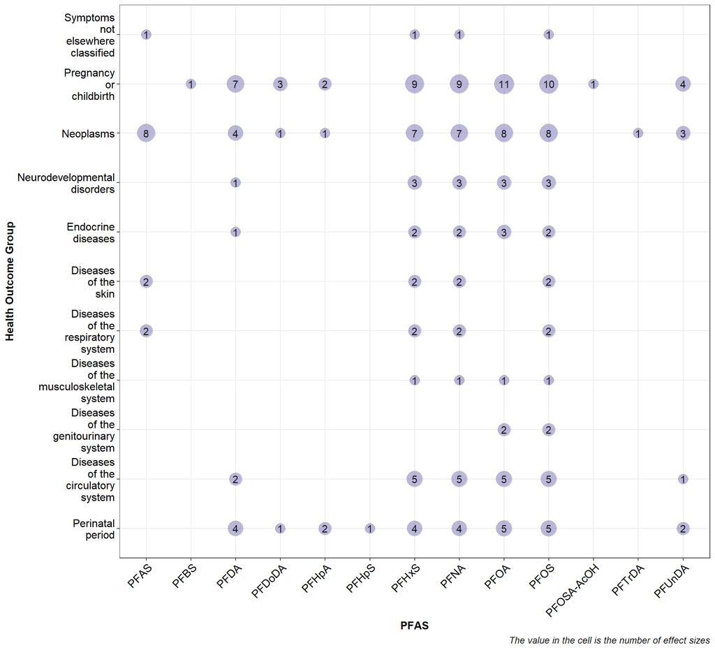

## Quantitative Synthesis

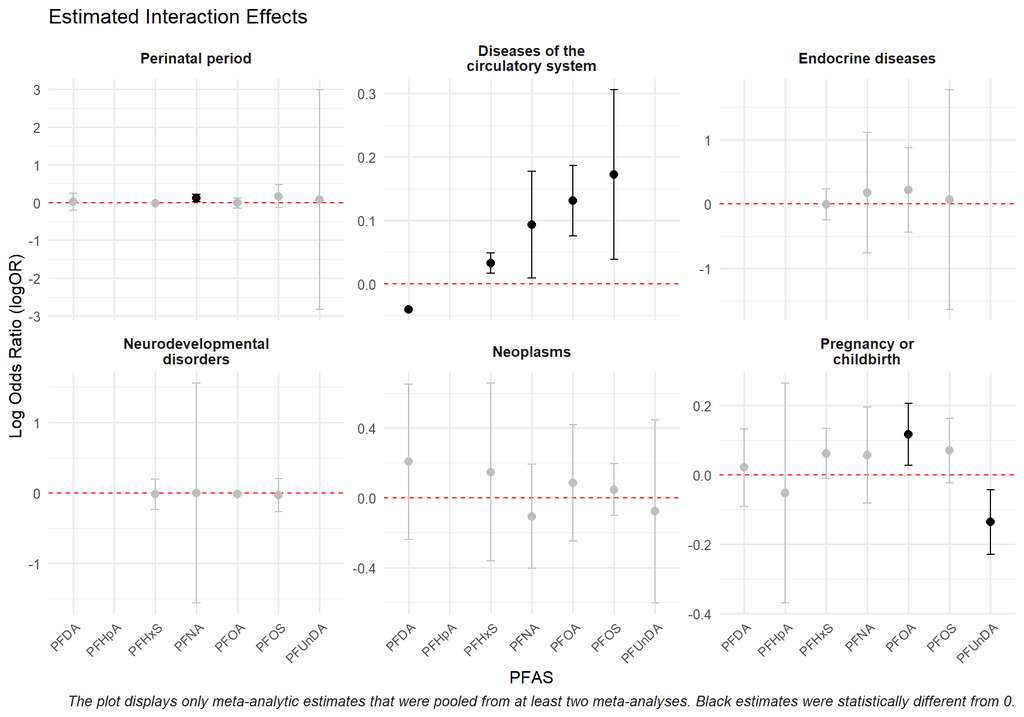

## Summary Results

**1)** Five health outcome groups out of eleven did not have more than one meta-analytic estimate for any chemical compound.

# Fourth Research Question

**Question:** How consistent are the findings regarding PFAS-health outcome associations across different meta-analyses?